# 7002HW2

# Q1 - Default Data from ISLR

## Q1.1

Fit a logistic regression with student as the X variable and default as the response variable.  
Interpret the coefficients and discuss whether the X variable is significant.

```r
Q1.1    <- ISLR::Default
dim(Q1.1)
```

```
## [1] 10000     4
```

```r
names(Q1.1)
```

```
## [1] "default" "student" "balance" "income"
```

```r
str(Q1.1)
```

```
## 'data.frame':    10000 obs. of  4 variables:
##  $ default: Factor w/ 2 levels "No","Yes": 1 1 1 1 1 1 1 1 1 1 ...
##  $ student: Factor w/ 2 levels "No","Yes": 1 2 1 1 1 2 1 2 1 1 ...
##  $ balance: num  730 817 1074 529 786 ...
##  $ income : num  44362 12106 31767 35704 38463 ...
```

```r
mutate(Q1.1, student=as.factor(student),
             default=as.factor(default))
```

[output not shown]

[output cut: 9986 more lines]

```r
fit1.1 <- glm(default~student, Q1.1, family=binomial(logit))
summary(fit1.1)
```

```
##
## Call:
## glm(formula = default ~ student, family = binomial(logit), data = Q1.1)
##
## Coefficients:
##             Estimate Std. Error z value Pr(>|z|)
## (Intercept) -3.50413    0.07071  -49.55  < 2e-16 ***
## studentYes   0.40489    0.11502    3.52 0.000431 ***
## ---
## Signif. codes:  0 '***' 0.001 '**' 0.01 '*' 0.05 '.' 0.1 ' ' 1
##
## (Dispersion parameter for binomial family taken to be 1)
##
##     Null deviance: 2920.6  on 9999  degrees of freedom
## Residual deviance: 2908.7  on 9998  degrees of freedom
## AIC: 2912.7
##
## Number of Fisher Scoring iterations: 6
```

Because p-value is 0.0004 < 0.05, student is a significant variable in this case.

## Q1.2

For the above logistic regression, one can actually obtain explicit expression of the maximum likelihood estimates of the coefficients.  
Please do the following:

### i

Write down the logistic regression model by coding student using one dummy variable: 0 for students and 1 for non-students.

$$log(\frac{P(default=Yes\vert X)}{1-P(default=Yes\vert X)}) =
\beta_0+\beta_1*I_{x=studentNo}+\epsilon$$

### ii

Write down the corresponding likelihood function.

$$P(default=Yes\vert Nostudent) =
\frac{e^{\beta_0+\beta_1studentNo}}{1+e^{\beta_0+\beta_1studentNo}}\\
P(default=Yes\vert student) = \frac{e^{\beta_0}}{1+e^{\beta_0}}\\
L(\beta_0,\beta_1)=\\(\frac{e^{\beta_0+\beta_1}}{1+e^{\beta_0+\beta_1}})^{n_{(Default=1|NoStudent
=1)}}*(\frac{1}{1+e^{\beta_0+\beta_1}})^{n_{(Default=0|NoStudent
=1)}}*(\frac{e^{\beta_0}}{1+e^{\beta_0}})^{n_{(Default=1|NoStudent
=0)}}*(\frac{1}{1+e^{\beta_0}})^{n_{(Default=0|NoStudent =0)}}\\$$

### iii

Obtain expressions for the coefficient estimates, and compare them with the answers in Q1.1.

```r
Q1.2 <- Q1.1
for (i in 1:nrow(Q1.2))
{
  if (Q1.2[i,2]=="Yes")
  {
    Q1.2[i,5] <- 0
  }
  else
  {
    Q1.2[i,5] <- 1
  }
}
colnames(Q1.2)[5] <- "studentNo"
```

```r
fit1.2 <- glm(Q1.2$default ~ Q1.2$studentNo, family = binomial(logit))
summary(fit1.2)
```

```
##
## Call:
## glm(formula = Q1.2$default ~ Q1.2$studentNo, family = binomial(logit))
##
## Coefficients:
##                Estimate Std. Error z value Pr(>|z|)
## (Intercept)    -3.09924    0.09071  -34.16  < 2e-16 ***
## Q1.2$studentNo -0.40489    0.11502   -3.52 0.000431 ***
## ---
## Signif. codes:  0 '***' 0.001 '**' 0.01 '*' 0.05 '.' 0.1 ' ' 1
##
## (Dispersion parameter for binomial family taken to be 1)
##
##     Null deviance: 2920.6  on 9999  degrees of freedom
## Residual deviance: 2908.7  on 9998  degrees of freedom
## AIC: 2912.7
##
## Number of Fisher Scoring iterations: 6
```

It is different from the answers in Q1.1. Because in Q1.1, 1 for students and 0 for non-students. In Q1.2, 0 for students and 1 for non-students.

## Q1.3

### i

Consider all the variables and obtain the final logistic regression model.

```r
fit1.3 <- glm(default~., Q1.1, family=binomial(logit))
summary(fit1.3)
```

```
##
## Call:
## glm(formula = default ~ ., family = binomial(logit), data = Q1.1)
##
## Coefficients:
##               Estimate Std. Error z value Pr(>|z|)
## (Intercept) -1.087e+01  4.923e-01 -22.080  < 2e-16 ***
## studentYes  -6.468e-01  2.363e-01  -2.738  0.00619 **
## balance      5.737e-03  2.319e-04  24.738  < 2e-16 ***
## income       3.033e-06  8.203e-06   0.370  0.71152
## ---
## Signif. codes:  0 '***' 0.001 '**' 0.01 '*' 0.05 '.' 0.1 ' ' 1
##
## (Dispersion parameter for binomial family taken to be 1)
##
##     Null deviance: 2920.6  on 9999  degrees of freedom
## Residual deviance: 1571.5  on 9996  degrees of freedom
## AIC: 1579.5
##
## Number of Fisher Scoring iterations: 8
```

### ii

Compare the ROC curves for the model in Q1.1 and Q1.3, along with the corresponding AUC.

```r
pred_q1.1<-predict(fit1.1, newdata = Q1.1, type = "response")
Q1.1$pred1<-fit1.1$fitted.values

pred_q1.3<-predict(fit1.3, newdata = Q1.1, type = "response")
Q1.1$pred3<-fit1.3$fitted.values

roc_q1.1 <- roc(Q1.1$default,Q1.1$pred1, ci=T,auc = T)
roc_q1.3 <- roc(Q1.1$default,Q1.1$pred3, ci=T,auc = T)
```

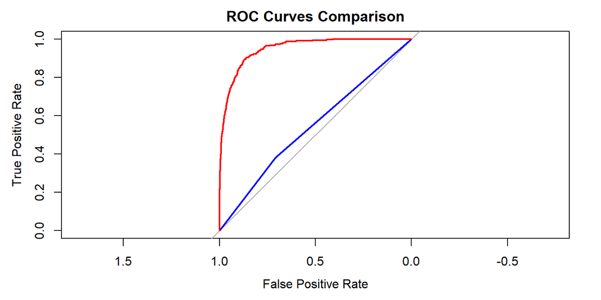

```r
plot(roc_q1.1, col = "blue", main = "ROC Curves Comparison", xlab = "False Positive Rate", ylab = "True Positive Rate")
plot(roc_q1.3, col = "red", add = TRUE)
```

```r
auc_q1.1 <- auc(roc_q1.1)
auc_q1.3 <- auc(roc_q1.3)
cat("AUC for Q1.1:", auc_q1.1, "\n")
```

```
## AUC for Q1.1: 0.5449888
```

```r
cat("AUC for Q1.3:", auc_q1.3, "\n")
```

```
## AUC for Q1.3: 0.9495581
```

### iii

Consider a threshold of 0.5 on the probability of default. Calculate the corresponding specificity, sensitivity, false positive rate, true positive rate.

```r
paste('specificity',length(Q1.1[Q1.1$default=='No'&Q1.1$pred3<0.5,1])/length(Q1.1[Q1.1$default=='No',1]))
```

```
## [1] "specificity 0.995862211647874"
```

```r
paste('sensitivity or true positive rate', length(Q1.1[Q1.1$default=='Yes'&Q1.1$pred3>0.5,1])/length(Q1.1[Q1.1$default=='Yes',1]))
```

```
## [1] "sensitivity or true positive rate 0.315315315315315"
```

```r
paste('false positive rate',length(Q1.1[Q1.1$default=='No'&Q1.1$pred3>0.5,1])/length(Q1.1[Q1.1$default=='No',1]))
```

```
## [1] "false positive rate 0.00413778835212579"
```

# Q2 - Lost Sales

In many industries throughout the world, suppliers compete for business by submitting quotes for work, services or products.  
A key criterion used to determine the winning quote is the dollar amount of the quote, but other factors include expected quality, estimated delivery time of the product, or quoted completion time of the work.

The focus of this case is a supplier of equipment to the automotive industry.  
The products of interest in this case are various precision metal components used in a range of automotive applications, such as braking systems, drive trains, and engines.  
Some of the products will be used in the manufacture or assembly of new automobiles (i.e. original equipment), while others will be used as replacement parts in automobiles already on the road(i.e. aftermarket).

The supplier wants to increase sales and expand its market position.  
Many of the quotes provided to prospective customers in the past haven’t resulted in orders.  
Do the data provide any indication why? Are there certain situations that make it more or less likely that a customer will place an order?

Please fit a model using the available data to explore these questions. Based on the fitted model, please provide your answers to the above questions.  
Drop insignificant variables for variable selection if you like.

The data set contains 550 records for quotes provided over a six month period.  
The variables in the data set are:  
Quote: The quoted price, in dollars, for the order Time to Delivery: The quoted number of calendar days within which the order is to be delivered Part Type: OE = original equipment; AM = aftermarket Status: Whether the quote resulted in a subsequent order within 30 days of receiving the quote: Lost = the order was not placed; Won = the order was placed.

```r
Q2  <- read.csv('lostsales.txt')
dim(Q2)
```

```
## [1] 550   4
```

```r
names(Q2)
```

```
## [1] "Quote"            "Time.to.Delivery" "Part.Type"        "Status"
```

```r
str(Q2)
```

```
## 'data.frame':    550 obs. of  4 variables:
##  $ Quote           : int  3452 429 102 1153 102 2313 2681 5486 845 1115 ...
##  $ Time.to.Delivery: int  6 9 14 16 11 46 63 35 16 40 ...
##  $ Part.Type       : chr  "OE" "AM" "OE" "OE" ...
##  $ Status          : chr  "Won" "Won" "Won" "Lost" ...
```

```r
apply(Q2, 2, function(x) sum(is.na(x)))
```

```
##            Quote Time.to.Delivery        Part.Type           Status
##                0                0                0                0
```

```r
Q2$Part.Type <- as.factor(Q2$Part.Type)
Q2$Status <- as.factor(Q2$Status)
```

```r
#fit all variables
fit2 <- glm(Status~., data = Q2, family = "binomial")
summary(fit2)
```

```
##
## Call:
## glm(formula = Status ~ ., family = "binomial", data = Q2)
##
## Coefficients:
##                    Estimate Std. Error z value Pr(>|z|)
## (Intercept)       7.768e-01  1.712e-01   4.537 5.70e-06 ***
## Quote            -1.931e-05  3.073e-05  -0.628   0.5299
## Time.to.Delivery -1.837e-02  3.483e-03  -5.274 1.34e-07 ***
## Part.TypeOE      -4.711e-01  1.968e-01  -2.394   0.0167 *
## ---
## Signif. codes:  0 '***' 0.001 '**' 0.01 '*' 0.05 '.' 0.1 ' ' 1
##
## (Dispersion parameter for binomial family taken to be 1)
##
##     Null deviance: 762.40  on 549  degrees of freedom
## Residual deviance: 723.83  on 546  degrees of freedom
## AIC: 731.83
##
## Number of Fisher Scoring iterations: 4
```

The p-values of both Time.to.Delivery and Part.Type are less then 0.05, hence they are significant variables. The p-value of Quote is 0.5299 > 0.05, hence Quote is not a significant variable.

```r
fit2.1 <- glm(Status~Time.to.Delivery+Part.Type, Q2, family=binomial(logit))
summary(fit2.1)
```

```
##
## Call:
## glm(formula = Status ~ Time.to.Delivery + Part.Type, family = binomial(logit),
##     data = Q2)
##
## Coefficients:
##                   Estimate Std. Error z value Pr(>|z|)
## (Intercept)       0.723499   0.148345   4.877 1.08e-06 ***
## Time.to.Delivery -0.018344   0.003484  -5.266 1.39e-07 ***
## Part.TypeOE      -0.475768   0.196582  -2.420   0.0155 *
## ---
## Signif. codes:  0 '***' 0.001 '**' 0.01 '*' 0.05 '.' 0.1 ' ' 1
##
## (Dispersion parameter for binomial family taken to be 1)
##
##     Null deviance: 762.40  on 549  degrees of freedom
## Residual deviance: 724.22  on 547  degrees of freedom
## AIC: 730.22
##
## Number of Fisher Scoring iterations: 4
```

```r
roc_q2 <- roc(Q2$Status,fit2.1$fitted.values)
```

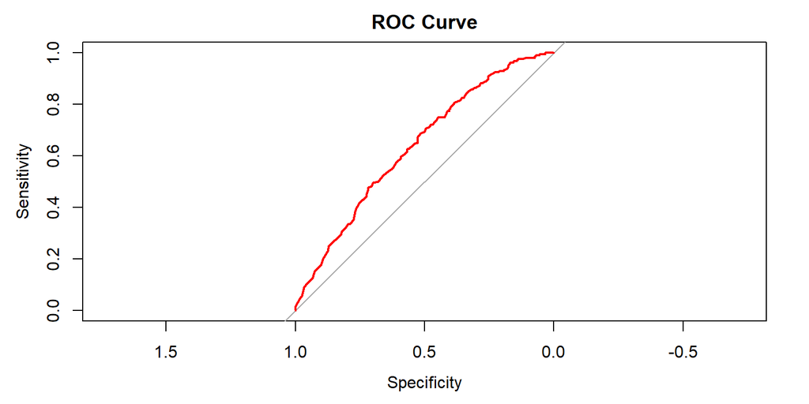

```r
plot(roc_q2, main = "ROC Curve", col = "red", lwd = 2)
```

```r
auc_q2 <- auc(roc_q2)
cat("AUC for Q2:", auc_q2, "\n")
```

```
## AUC for Q2: 0.6376428
```

According to the data above, Time.to.Delivery is a very significant variable. Holding that Part.Type is constant, if the supplier want to increase sales, he needs to shorten the delivery time. AUC-value is 0.638, suggesting that the model has a moderate ability to distinguish between won and lost orders.

# Q3 - Wine Quality

The wine quality data contain information on quality ratings for 6,497 different wines, along with measures of wine properties. The response variable is Quality.  
Please build a model to predict wine quality. Conduct exploratory data analysis and see if there are redundant or irrelevant information in the data.  
If so, remove them.  
Then consider two possible modelling choices: i. Multinomial logistic regression ii. Ordinal logistic regression Write up a summary about characteristics of Good quality wine for each model. Do you roughly get similar conclusions using those two models?

```r
Q3 <-read.csv('winequality-bc.txt')
dim(Q3)
```

```
## [1] 6497   16
```

```r
names(Q3)
```

```
##  [1] "Quality"              "fixed.acidity"        "volatile.acidity"
##  [4] "citric.acid"          "residual.sugar"       "chlorides"
##  [7] "free.sulfur.dioxide"  "total.sulfur.dioxide" "density"
## [10] "pH"                   "sulphates"            "alcohol"
## [13] "color"                "quality"              "Crossvalidation"
## [16] "Hold.Test"
```

```r
str(Q3)
```

```
## 'data.frame':    6497 obs. of  16 variables:
##  $ Quality             : chr  "Just OK" "Just OK" "Just OK" "Just OK" ...
##  $ fixed.acidity       : num  7.4 7.8 7.8 11.2 7.4 7.4 7.9 7.3 7.8 7.5 ...
##  $ volatile.acidity    : num  0.7 0.88 0.76 0.28 0.7 0.66 0.6 0.65 0.58 0.5 ...
##  $ citric.acid         : num  0 0 0.04 0.56 0 0 0.06 0 0.02 0.36 ...
##  $ residual.sugar      : num  1.9 2.6 2.3 1.9 1.9 1.8 1.6 1.2 2 6.1 ...
##  $ chlorides           : num  0.076 0.098 0.092 0.075 0.076 0.075 0.069 0.065 0.073 0.071 ...
##  $ free.sulfur.dioxide : num  11 25 15 17 11 13 15 15 9 17 ...
##  $ total.sulfur.dioxide: num  34 67 54 60 34 40 59 21 18 102 ...
##  $ density             : num  0.998 0.997 0.997 0.998 0.998 ...
##  $ pH                  : num  3.51 3.2 3.26 3.16 3.51 3.51 3.3 3.39 3.36 3.35 ...
##  $ sulphates           : num  0.56 0.68 0.65 0.58 0.56 0.56 0.46 0.47 0.57 0.8 ...
##  $ alcohol             : num  9.4 9.8 9.8 9.8 9.4 9.4 9.4 10 9.5 10.5 ...
##  $ color               : chr  "red" "red" "red" "red" ...
##  $ quality             : int  5 5 5 6 5 5 5 7 7 5 ...
##  $ Crossvalidation     : int  3 2 2 3 3 2 3 3 3 2 ...
##  $ Hold.Test           : int  0 1 1 0 0 0 0 0 0 0 ...
```

```r
apply(Q3, 2, function(x) sum(is.na(x)))
```

```
##              Quality        fixed.acidity     volatile.acidity
##                    0                    0                    0
##          citric.acid       residual.sugar            chlorides
##                    0                    0                    0
##  free.sulfur.dioxide total.sulfur.dioxide              density
##                    0                    0                    0
##                   pH            sulphates              alcohol
##                    0                    0                    0
##                color              quality      Crossvalidation
##                    0                    0                    0
##            Hold.Test
##                    0
```

```r
Q3$Quality <- as.factor(Q3$Quality)
Q3$color <- as.factor(Q3$color)
Q3$Hold.Test <- as.factor(Q3$Hold.Test)
Q3$Crossvalidation <- as.factor(Q3$Crossvalidation)
```

```r
q3_mult <- multinom(Quality~., data=Q3)
Anova(q3_mult)
```

```
## Analysis of Deviance Table (Type II tests)
##
## Response: Quality
##                      LR Chisq Df Pr(>Chisq)
## fixed.acidity             0.0  2          1
## volatile.acidity          0.0  2          1
## citric.acid               0.0  2          1
## residual.sugar            0.0  2          1
## chlorides                 0.0  2          1
## free.sulfur.dioxide       0.0  2          1
## total.sulfur.dioxide      0.0  2          1
## density                   0.0  2          1
## pH                        0.0  2          1
## sulphates                 0.0  2          1
## alcohol                   0.0  2          1
## color                     0.0  2          1
## quality                6790.3  2     <2e-16 ***
## Crossvalidation           0.0  4          1
## Hold.Test                 0.0  4          1
## ---
## Signif. codes:  0 '***' 0.001 '**' 0.01 '*' 0.05 '.' 0.1 ' ' 1
```

According to the p-values, only quality is a significant variable.

```r
q3_mult2 <- multinom(Quality~fixed.acidity+volatile.acidity+residual.sugar+chlorides+free.sulfur.dioxide+density+pH+sulphates+alcohol+color+Crossvalidation+Hold.Test, data=Q3)
Anova(q3_mult2)
```

```
## Analysis of Deviance Table (Type II tests)
##
## Response: Quality
##                     LR Chisq Df Pr(>Chisq)
## fixed.acidity         61.323  2  4.830e-14 ***
## volatile.acidity     264.526  2  < 2.2e-16 ***
## residual.sugar        85.199  2  < 2.2e-16 ***
## chlorides              9.345  2   0.009348 **
## free.sulfur.dioxide   38.833  2  3.695e-09 ***
## density               51.831  2  5.559e-12 ***
## pH                    56.891  2  4.428e-13 ***
## sulphates             72.807  2  < 2.2e-16 ***
## alcohol               30.718  2  2.137e-07 ***
## color                129.992  2  < 2.2e-16 ***
## Crossvalidation       -0.066  4   1.000000
## Hold.Test             11.675  4   0.019940 *
## ---
## Signif. codes:  0 '***' 0.001 '**' 0.01 '*' 0.05 '.' 0.1 ' ' 1
```

Choosing those p-values < 0.05: fixed.acidity + volatile.acidity + residual.sugar + chlorides + free.sulfur.dioxide + density + pH + sulphates + alcohol + color + Hold.Test These variables above are significant.

```r
q3_mult_final <- polr(Quality~fixed.acidity +volatile.acidity+ residual.sugar+chlorides+free.sulfur.dioxide+density+pH+sulphates+alcohol+color+Hold.Test,data=Q3)
summary(q3_mult_final)
```

```
##
## Re-fitting to get Hessian
```

```
## Call:
## polr(formula = Quality ~ fixed.acidity + volatile.acidity + residual.sugar +
##     chlorides + free.sulfur.dioxide + density + pH + sulphates +
##     alcohol + color + Hold.Test, data = Q3)
##
## Coefficients:
##                          Value Std. Error   t value
## fixed.acidity        -0.413474   0.032752 -12.62452
## volatile.acidity     -0.065404   0.272390  -0.24011
## residual.sugar       -0.124115   0.008459 -14.67229
## chlorides             2.622227   1.567686   1.67267
## free.sulfur.dioxide   0.002862   0.002249   1.27243
## density             305.930430   0.540526 565.98681
## pH                   -2.102296   0.241295  -8.71255
## sulphates            -1.450848   0.236387  -6.13760
## alcohol              -0.257917   0.029080  -8.86927
## colorwhite           -0.183462   0.144080  -1.27333
## Hold.Test1           -0.073048   0.077904  -0.93767
## Hold.Test2            0.007433   0.081406   0.09131
##
## Intercepts:
##              Value    Std. Error t value
## Bad|Good     286.8652   0.5503   521.2861
## Good|Just OK 289.0744   0.5472   528.3075
##
## Residual Deviance: 7660.705
## AIC: 7688.705
```

```r
Q3$Quality <- factor(Q3$Quality,levels = c("Bad","Just OK","Good"),ordered = TRUE)

q3_ord <- polr(Quality~fixed.acidity +volatile.acidity+citric.acid+ residual.sugar+chlorides+free.sulfur.dioxide+total.sulfur.dioxide+density+pH+sulphates+alcohol+color+Crossvalidation+Hold.Test,data=Q3)
Anova(q3_ord)
```

```
## Analysis of Deviance Table (Type II tests)
##
## Response: Quality
##                      LR Chisq Df Pr(>Chisq)
## fixed.acidity          41.309  1  1.300e-10 ***
## volatile.acidity      179.446  1  < 2.2e-16 ***
## citric.acid             0.007  1    0.93475
## residual.sugar        102.961  1  < 2.2e-16 ***
## chlorides               6.174  1    0.01296 *
## free.sulfur.dioxide    23.542  1  1.222e-06 ***
## total.sulfur.dioxide    2.162  1    0.14142
## density                65.616  1  5.480e-16 ***
## pH                     34.139  1  5.132e-09 ***
## sulphates              69.607  1  < 2.2e-16 ***
## alcohol                39.739  1  2.902e-10 ***
## color                  53.189  1  3.029e-13 ***
## Crossvalidation         0.489  2    0.78328
## Hold.Test               4.030  2    0.13330
## ---
## Signif. codes:  0 '***' 0.001 '**' 0.01 '*' 0.05 '.' 0.1 ' ' 1
```

Choosing those p-values < 0.05: fixed.acidity + volatile.acidity + residual.sugar + chlorides + free.sulfur.dioxide + density + pH + sulphates + alcohol + color These variables above are significant.

```r
q3_ord_final <- polr(Quality~fixed.acidity +volatile.acidity+ residual.sugar+chlorides+free.sulfur.dioxide+density+pH+sulphates+alcohol+color,data=Q3)
summary(q3_ord_final)
```

```
##
## Re-fitting to get Hessian
```

```
## Call:
## polr(formula = Quality ~ fixed.acidity + volatile.acidity + residual.sugar +
##     chlorides + free.sulfur.dioxide + density + pH + sulphates +
##     alcohol + color, data = Q3)
##
## Coefficients:
##                          Value Std. Error  t value
## fixed.acidity          0.36205   0.033516   10.802
## volatile.acidity      -3.97250   0.271026  -14.657
## residual.sugar         0.21591   0.008416   25.656
## chlorides             -3.09487   1.222677   -2.531
## free.sulfur.dioxide    0.01092   0.002238    4.878
## density             -419.07277   0.537942 -779.029
## pH                     1.85456   0.246524    7.523
## sulphates              2.11945   0.242269    8.748
## alcohol                0.42374   0.032248   13.140
## colorwhite            -1.60715   0.139158  -11.549
##
## Intercepts:
##              Value     Std. Error t value
## Bad|Just OK  -407.8371    0.5467  -745.9398
## Just OK|Good -402.1183    0.5635  -713.5650
##
## Residual Deviance: 7008.946
## AIC: 7032.946
```